# Part 3: Customer Lifetime Value Prediction

One of the most important metric we should estimate and tract is the Customer lifetime value.

Company invests in customers (acquisition costs, offline ads, promotions, discounts & etc.) to generate revenue and be profitable. Naturally, these actions make some customers super valuable in terms of lifetime value but there are always some customers who pull down the profitability. We need to identify these behavior patterns, segment customers and act accordingly.

To calculate lifetime value we need to select a time window. It can be anything like 3, 6, 12, 24 months. By the equation below, we can calculate lifetime value for each customer in that specific time window:

> **Lifetime Value**: Total Gross Revenue - Total Cost

This equation gives us the historical lifetime value. If we see some customers having very high negative lifetime value historically, it could be too late to take an action. At this point, we need to predict the future with machine learning.

Let’s identify our path to predicting lifetime value:

- Define an appropriate time frame for Customer Lifetime Value calculation
- Identify the features we are going to use to predict future and create them
- Calculate lifetime value (LTV) for training the machine learning model
- Build and run the machine learning model
- Check if the model is useful

## Load the dataset

|  | InvoiceNo | StockCode | Description | Quantity | InvoiceDate | UnitPrice | CustomerID | Country |
| --- | --- | --- | --- | --- | --- | --- | --- | --- |
| 0 | 536365 | 85123A | WHITE HANGING HEART T-LIGHT HOLDER | 6 | 2010-12-01 08:26:00 | 2.55 | 17850.0 | United Kingdom |
| 1 | 536365 | 71053 | WHITE METAL LANTERN | 6 | 2010-12-01 08:26:00 | 3.39 | 17850.0 | United Kingdom |
| 2 | 536365 | 84406B | CREAM CUPID HEARTS COAT HANGER | 8 | 2010-12-01 08:26:00 | 2.75 | 17850.0 | United Kingdom |
| 3 | 536365 | 84029G | KNITTED UNION FLAG HOT WATER BOTTLE | 6 | 2010-12-01 08:26:00 | 3.39 | 17850.0 | United Kingdom |
| 4 | 536365 | 84029E | RED WOOLLY HOTTIE WHITE HEART. | 6 | 2010-12-01 08:26:00 | 3.39 | 17850.0 | United Kingdom |

```
(3951,)
```

## Lifetime value prediction

### Time Frame

Deciding the time frame really depends on your industry, business model, strategy and more. For some industries, 1 year is a very long period while for the others it is very short. In our example, we will go ahead with **6 months**.

### Features

RFM scores for each customer ID (which we calculated in the previous article) are the perfect candidates for feature set.

To implement it correctly, we need to split our dataset. We will take 3 months of data, calculate RFM and use it for predicting next 6 months. So we need to create two dataframes first and append RFM scores to them.

```
count                  541909
unique                  23260
top       2011-10-31 14:41:00
freq                     1114
first     2010-12-01 08:26:00
last      2011-12-09 12:50:00
Name: InvoiceDate, dtype: object
```

```
count                   95193
unique                   4852
top       2011-04-18 13:13:00
freq                      333
first     2011-03-01 08:30:00
last      2011-05-31 15:53:00
Name: InvoiceDate, dtype: object
```

```
count                  278966
unique                  11477
top       2011-10-31 14:41:00
freq                     1114
first     2011-06-01 07:37:00
last      2011-11-30 17:42:00
Name: InvoiceDate, dtype: object
```

|  | CustomerID | Recency | RecencyCluster | Frequency | FrequencyCluster | Revenue | RevenueCluster | OverallScore | Segment |
| --- | --- | --- | --- | --- | --- | --- | --- | --- | --- |
| 0 | 14620.0 | 12 | 3 | 30 | 0 | 393.28 | 0 | 3 | Mid-Value |
| 1 | 15194.0 | 6 | 3 | 64 | 0 | 1439.02 | 0 | 3 | Mid-Value |
| 2 | 18044.0 | 5 | 3 | 57 | 0 | 808.96 | 0 | 3 | Mid-Value |
| 3 | 18075.0 | 12 | 3 | 35 | 0 | 638.12 | 0 | 3 | Mid-Value |
| 4 | 15241.0 | 0 | 3 | 64 | 0 | 947.55 | 0 | 3 | Mid-Value |

We have created our RFM scoring and now our feature set looks like above. Check customer scores on Recency, Frequency and Revenue accross Segments.

| Segment | Recency | Frequency | Revenue |
| --- | --- | --- | --- |
| Low-Value | 49.650767 | 25.112436 | 394.738365 |
| Mid-Value | 9.812601 | 50.442649 | 910.635058 |
| High-Value | 6.468085 | 233.553191 | 7066.589149 |

[interactive chart not shown]

#### Calculate lifetime value (LTV)

Since our feature set is ready, let’s calculate 6 months LTV for each customer which we are going to use for training our model. There is no cost specified in the dataset. That’s why Revenue becomes our LTV directly.

|  | InvoiceNo | StockCode | Description | Quantity | InvoiceDate | UnitPrice | CustomerID | Country |
| --- | --- | --- | --- | --- | --- | --- | --- | --- |
| 0 | 555156 | 23299 | FOOD COVER WITH BEADS SET 2 | 6 | 2011-06-01 07:37:00 | 3.75 | 15643.0 | United Kingdom |
| 1 | 555156 | 22847 | BREAD BIN DINER STYLE IVORY | 1 | 2011-06-01 07:37:00 | 16.95 | 15643.0 | United Kingdom |
| 2 | 555157 | 23075 | PARLOUR CERAMIC WALL HOOK | 16 | 2011-06-01 07:38:00 | 4.15 | 15643.0 | United Kingdom |
| 3 | 555157 | 47590B | PINK HAPPY BIRTHDAY BUNTING | 6 | 2011-06-01 07:38:00 | 5.45 | 15643.0 | United Kingdom |
| 4 | 555157 | 22423 | REGENCY CAKESTAND 3 TIER | 4 | 2011-06-01 07:38:00 | 12.75 | 15643.0 | United Kingdom |

|  | CustomerID | m6_Revenue |
| --- | --- | --- |
| 0 | 12747.0 | 1666.11 |
| 1 | 12748.0 | 18679.01 |
| 2 | 12749.0 | 2323.04 |
| 3 | 12820.0 | 561.53 |
| 4 | 12822.0 | 918.98 |

```
count      3167.000000
mean       1239.685078
std        4782.390775
min       -4287.630000
25%         257.780000
50%         521.200000
75%        1148.670000
max      180469.050000
Name: m6_Revenue, dtype: float64
```

[interactive chart not shown]

Histogram clearly shows we have customers with negative LTV. We have some outliers too. Filtering out the outliers makes sense to have a proper machine learning model.

Next step is to merge our 3 months and 6 months dataframes to see correlations between LTV and the feature set we have.

|  | CustomerID | Recency | RecencyCluster | Frequency | FrequencyCluster | Revenue | RevenueCluster | OverallScore | Segment | m6_Revenue |
| --- | --- | --- | --- | --- | --- | --- | --- | --- | --- | --- |
| 0 | 14620.0 | 12 | 3 | 30 | 0 | 393.28 | 0 | 3 | Mid-Value | NaN |
| 1 | 15194.0 | 6 | 3 | 64 | 0 | 1439.02 | 0 | 3 | Mid-Value | 3232.20 |
| 2 | 18044.0 | 5 | 3 | 57 | 0 | 808.96 | 0 | 3 | Mid-Value | 991.54 |
| 3 | 18075.0 | 12 | 3 | 35 | 0 | 638.12 | 0 | 3 | Mid-Value | 1322.75 |
| 4 | 15241.0 | 0 | 3 | 64 | 0 | 947.55 | 0 | 3 | Mid-Value | 791.04 |

```
Segment
High-Value    17658.143830
Low-Value       703.559983
Mid-Value      1715.514913
Name: m6_Revenue, dtype: float64
```

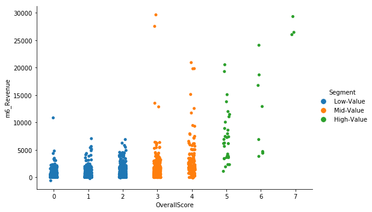

[interactive chart not shown]

Positive correlation is quite visible here. High RFM score means high LTV.

#### LTV Segments

Before building the machine learning model, we need to identify what is the type of this machine learning problem. LTV itself is a regression problem. A machine learning model can predict the `$value` of the LTV. But here, we want *LTV segments*. Because it makes it more actionable and easy to communicate with other people. By applying K-means clustering, we can identify our existing LTV groups and build segments on top of it.

Considering business part of this analysis, we need to treat customers differently based on their predicted LTV. For this example, we will apply clustering and have 3 segments (number of segments really depends on your business dynamics and goals):

- Low LTV
- Mid LTV
- High LTV

We are going to apply K-means clustering to decide segments and observe their characteristics:

|  | CustomerID | Recency | RecencyCluster | Frequency | FrequencyCluster | Revenue | RevenueCluster | OverallScore | Segment | m6_Revenue | LTVCluster |
| --- | --- | --- | --- | --- | --- | --- | --- | --- | --- | --- | --- |
| 0 | 14620.0 | 12 | 3 | 30 | 0 | 393.28 | 0 | 3 | Mid-Value | 0.00 | 1 |
| 1 | 15194.0 | 6 | 3 | 64 | 0 | 1439.02 | 0 | 3 | Mid-Value | 3232.20 | 0 |
| 2 | 18044.0 | 5 | 3 | 57 | 0 | 808.96 | 0 | 3 | Mid-Value | 991.54 | 1 |
| 3 | 18075.0 | 12 | 3 | 35 | 0 | 638.12 | 0 | 3 | Mid-Value | 1322.75 | 1 |
| 4 | 15241.0 | 0 | 3 | 64 | 0 | 947.55 | 0 | 3 | Mid-Value | 791.04 | 1 |

| LTVCluster | count | mean | std | min | 25% | 50% | 75% | max |
| --- | --- | --- | --- | --- | --- | --- | --- | --- |
| 0 | 1394.0 | 396.137189 | 419.891843 | -609.40 | 0.000 | 294.220 | 682.4300 | 1429.87 |
| 1 | 371.0 | 2492.794933 | 937.341566 | 1445.31 | 1731.980 | 2162.930 | 3041.9550 | 5287.39 |
| 2 | 56.0 | 8222.565893 | 2983.572030 | 5396.44 | 6151.435 | 6986.545 | 9607.3225 | 16756.31 |

We have finished LTV clustering and now have 3 clusters where cluster 2 is the best with average 8.2k LTV whereas cluster 0 is the worst with 396.

#### Prepare data for machine learning

There are few more steps before training the machine learning model:

- We need to do some feature engineering. We should convert categorical columns to numerical columns.
- We will check the correlation of features against our label, LTV clusters.
- Split data into features and lables (X, y) and create training and test sets.

|  | CustomerID | Recency | RecencyCluster | Frequency | FrequencyCluster | Revenue | RevenueCluster | OverallScore | m6_Revenue | LTVCluster | Segment_High-Value | Segment_Low-Value | Segment_Mid-Value |
| --- | --- | --- | --- | --- | --- | --- | --- | --- | --- | --- | --- | --- | --- |
| 0 | 14620.0 | 12 | 3 | 30 | 0 | 393.28 | 0 | 3 | 0.00 | 0 | 0 | 0 | 1 |
| 1 | 18044.0 | 5 | 3 | 57 | 0 | 808.96 | 0 | 3 | 991.54 | 0 | 0 | 0 | 1 |
| 2 | 18075.0 | 12 | 3 | 35 | 0 | 638.12 | 0 | 3 | 1322.75 | 0 | 0 | 0 | 1 |
| 3 | 15241.0 | 0 | 3 | 64 | 0 | 947.55 | 0 | 3 | 791.04 | 0 | 0 | 0 | 1 |
| 4 | 15660.0 | 4 | 3 | 34 | 0 | 484.62 | 0 | 3 | 858.09 | 0 | 0 | 0 | 1 |

```
LTVCluster            1.000000
Revenue               0.600491
RevenueCluster        0.463930
OverallScore          0.373231
FrequencyCluster      0.366366
Frequency             0.359601
Segment_High-Value    0.353218
RecencyCluster        0.236899
Segment_Mid-Value     0.166854
CustomerID           -0.028401
Recency              -0.237249
Segment_Low-Value    -0.266008
Name: LTVCluster, dtype: float64
```

We see that 3 features Revenue, OverallScore and Frequency will be helpful for our machine learning models.

**Note**: we cannot user m6_Revenue as it comes from dataset used to generate label.

#### Build and run the machine learning model

Since we have the training and test sets we can build our model.

```
XGBClassifier(base_score=0.5, booster='gbtree', colsample_bylevel=1,
       colsample_bynode=1, colsample_bytree=1, gamma=0, learning_rate=0.1,
       max_delta_step=0, max_depth=5, min_child_weight=1, missing=None,
       n_estimators=100, n_jobs=-1, nthread=None,
       objective='multi:softprob', random_state=0, reg_alpha=0,
       reg_lambda=1, scale_pos_weight=1, seed=None, silent=None,
       subsample=1, verbosity=1)
```

#### Check if the model is useful

We used a quite strong XGBoost ML library to do the classification for us. It has become a multi classification model since we had 3 groups (clusters). Let’s look at the initial results:

```
Accuracy of XGB classifier on training set: 0.92
Accuracy of XGB classifier on test set: 0.78
```

```
LTVCluster
0    0.765513
1    0.203734
2    0.030752
Name: CustomerID, dtype: float64
```

First we need to check our benchmark. Biggest cluster we have is cluster 0 which is 76.5% of the total base. If we blindly say, every customer belongs to cluster 0, then our accuracy would be 76.5%.

We can identify that by looking at classification report:

```
              precision    recall  f1-score   support

           0       0.84      0.91      0.88       140
           1       0.42      0.30      0.35        37
           2       0.60      0.50      0.55         6

   micro avg       0.78      0.78      0.78       183
   macro avg       0.62      0.57      0.59       183
weighted avg       0.75      0.78      0.76       183
```

- Adding more features and improve feature engineering
- Try different models other than XGBoost
- Apply hyper parameter tuning to current model
- Add more data to the model if possible

Great! Now we have a machine learning model which predicts the future LTV segments of our customers. We can easily adapt our actions based on that. For example, we definitely do not want to lose customers with high LTV. So we will focus on Churn Prediction in Part 4.